# Tree-Based Models

## Regression Tree

```python
import pandas as pd
import numpy as np
import matplotlib.pyplot as plt
```

```python
Hitters=pd.read_csv('Hitters.csv')
Hitters.head()
```

|  | Unnamed: 0 | AtBat | Hits | HmRun | Runs | RBI | Walks | Years | CAtBat | CHits | ... | CRuns | CRBI | CWalks | League | Division | PutOuts | Assists | Errors | Salary | NewLeague |
| --- | --- | --- | --- | --- | --- | --- | --- | --- | --- | --- | --- | --- | --- | --- | --- | --- | --- | --- | --- | --- | --- |
| 0 | -Andy Allanson | 293 | 66 | 1 | 30 | 29 | 14 | 1 | 293 | 66 | ... | 30 | 29 | 14 | A | E | 446 | 33 | 20 | NaN | A |
| 1 | -Alan Ashby | 315 | 81 | 7 | 24 | 38 | 39 | 14 | 3449 | 835 | ... | 321 | 414 | 375 | N | W | 632 | 43 | 10 | 475.0 | N |
| 2 | -Alvin Davis | 479 | 130 | 18 | 66 | 72 | 76 | 3 | 1624 | 457 | ... | 224 | 266 | 263 | A | W | 880 | 82 | 14 | 480.0 | A |
| 3 | -Andre Dawson | 496 | 141 | 20 | 65 | 78 | 37 | 11 | 5628 | 1575 | ... | 828 | 838 | 354 | N | E | 200 | 11 | 3 | 500.0 | N |
| 4 | -Andres Galarraga | 321 | 87 | 10 | 39 | 42 | 30 | 2 | 396 | 101 | ... | 48 | 46 | 33 | N | E | 805 | 40 | 4 | 91.5 | N |

5 rows × 21 columns

```python
Hitters.rename(columns = {'Unnamed: 0':'Name'}, inplace = True)
Hitters.head()
```

|  | Name | AtBat | Hits | HmRun | Runs | RBI | Walks | Years | CAtBat | CHits | ... | CRuns | CRBI | CWalks | League | Division | PutOuts | Assists | Errors | Salary | NewLeague |
| --- | --- | --- | --- | --- | --- | --- | --- | --- | --- | --- | --- | --- | --- | --- | --- | --- | --- | --- | --- | --- | --- |
| 0 | -Andy Allanson | 293 | 66 | 1 | 30 | 29 | 14 | 1 | 293 | 66 | ... | 30 | 29 | 14 | A | E | 446 | 33 | 20 | NaN | A |
| 1 | -Alan Ashby | 315 | 81 | 7 | 24 | 38 | 39 | 14 | 3449 | 835 | ... | 321 | 414 | 375 | N | W | 632 | 43 | 10 | 475.0 | N |
| 2 | -Alvin Davis | 479 | 130 | 18 | 66 | 72 | 76 | 3 | 1624 | 457 | ... | 224 | 266 | 263 | A | W | 880 | 82 | 14 | 480.0 | A |
| 3 | -Andre Dawson | 496 | 141 | 20 | 65 | 78 | 37 | 11 | 5628 | 1575 | ... | 828 | 838 | 354 | N | E | 200 | 11 | 3 | 500.0 | N |
| 4 | -Andres Galarraga | 321 | 87 | 10 | 39 | 42 | 30 | 2 | 396 | 101 | ... | 48 | 46 | 33 | N | E | 805 | 40 | 4 | 91.5 | N |

5 rows × 21 columns

We see that there are some NA values in the dataset. We first remove those rows.

```python
Hitters = Hitters.dropna()
Hitters.head()
```

|  | Name | AtBat | Hits | HmRun | Runs | RBI | Walks | Years | CAtBat | CHits | ... | CRuns | CRBI | CWalks | League | Division | PutOuts | Assists | Errors | Salary | NewLeague |
| --- | --- | --- | --- | --- | --- | --- | --- | --- | --- | --- | --- | --- | --- | --- | --- | --- | --- | --- | --- | --- | --- |
| 1 | -Alan Ashby | 315 | 81 | 7 | 24 | 38 | 39 | 14 | 3449 | 835 | ... | 321 | 414 | 375 | N | W | 632 | 43 | 10 | 475.0 | N |
| 2 | -Alvin Davis | 479 | 130 | 18 | 66 | 72 | 76 | 3 | 1624 | 457 | ... | 224 | 266 | 263 | A | W | 880 | 82 | 14 | 480.0 | A |
| 3 | -Andre Dawson | 496 | 141 | 20 | 65 | 78 | 37 | 11 | 5628 | 1575 | ... | 828 | 838 | 354 | N | E | 200 | 11 | 3 | 500.0 | N |
| 4 | -Andres Galarraga | 321 | 87 | 10 | 39 | 42 | 30 | 2 | 396 | 101 | ... | 48 | 46 | 33 | N | E | 805 | 40 | 4 | 91.5 | N |
| 5 | -Alfredo Griffin | 594 | 169 | 4 | 74 | 51 | 35 | 11 | 4408 | 1133 | ... | 501 | 336 | 194 | A | W | 282 | 421 | 25 | 750.0 | A |

5 rows × 21 columns

As indicated in the lecture notes, we transform the salary to log-salary

```python
Hitters["log-salary"]=np.log(Hitters.Salary)
Hitters.head()
```

|  | Name | AtBat | Hits | HmRun | Runs | RBI | Walks | Years | CAtBat | CHits | ... | CRBI | CWalks | League | Division | PutOuts | Assists | Errors | Salary | NewLeague | log-salary |
| --- | --- | --- | --- | --- | --- | --- | --- | --- | --- | --- | --- | --- | --- | --- | --- | --- | --- | --- | --- | --- | --- |
| 1 | -Alan Ashby | 315 | 81 | 7 | 24 | 38 | 39 | 14 | 3449 | 835 | ... | 414 | 375 | N | W | 632 | 43 | 10 | 475.0 | N | 6.163315 |
| 2 | -Alvin Davis | 479 | 130 | 18 | 66 | 72 | 76 | 3 | 1624 | 457 | ... | 266 | 263 | A | W | 880 | 82 | 14 | 480.0 | A | 6.173786 |
| 3 | -Andre Dawson | 496 | 141 | 20 | 65 | 78 | 37 | 11 | 5628 | 1575 | ... | 838 | 354 | N | E | 200 | 11 | 3 | 500.0 | N | 6.214608 |
| 4 | -Andres Galarraga | 321 | 87 | 10 | 39 | 42 | 30 | 2 | 396 | 101 | ... | 46 | 33 | N | E | 805 | 40 | 4 | 91.5 | N | 4.516339 |
| 5 | -Alfredo Griffin | 594 | 169 | 4 | 74 | 51 | 35 | 11 | 4408 | 1133 | ... | 336 | 194 | A | W | 282 | 421 | 25 | 750.0 | A | 6.620073 |

5 rows × 22 columns

```python
from sklearn.tree import DecisionTreeRegressor
```

```python
from sklearn.model_selection import train_test_split
X_train, X_test, y_train, y_test = train_test_split(Hitters[["Hits","Years"]], Hitters["log-salary"],train_size=int(0.8*len(Hitters)), random_state=42)
print(len(X_train))
len(X_test)
```

```
210
```

```
53
```

```python
help(DecisionTreeRegressor)
```

```
Help on class DecisionTreeRegressor in module sklearn.tree._classes:

class DecisionTreeRegressor(sklearn.base.RegressorMixin, BaseDecisionTree)
 |  DecisionTreeRegressor(*, criterion='mse', splitter='best', max_depth=None, min_samples_split=2, min_samples_leaf=1, min_weight_fraction_leaf=0.0, max_features=None, random_state=None, max_leaf_nodes=None, min_impurity_decrease=0.0, min_impurity_split=None, presort='deprecated', ccp_alpha=0.0)
 |  A decision tree regressor.
 |  Read more in the :ref:`User Guide <tree>`.
 |  Parameters
 |  ----------
 |  criterion : {"mse", "friedman_mse", "mae"}, default="mse"
 |      The function to measure the quality of a split. Supported criteria
 |      are "mse" for the mean squared error, which is equal to variance
 |      reduction as feature selection criterion and minimizes the L2 loss
 |      using the mean of each terminal node, "friedman_mse", which uses mean
 |      squared error with Friedman's improvement score for potential splits,
 |      and "mae" for the mean absolute error, which minimizes the L1 loss
 |      using the median of each terminal node.
 |      .. versionadded:: 0.18
 |         Mean Absolute Error (MAE) criterion.
 |  splitter : {"best", "random"}, default="best"
 |      The strategy used to choose the split at each node. Supported
 |      strategies are "best" to choose the best split and "random" to choose
 |      the best random split.
 |  max_depth : int, default=None
 |      The maximum depth of the tree. If None, then nodes are expanded until
 |      all leaves are pure or until all leaves contain less than
 |      min_samples_split samples.
 |  min_samples_split : int or float, default=2
 |      The minimum number of samples required to split an internal node:
 |      - If int, then consider `min_samples_split` as the minimum number.
 |      - If float, then `min_samples_split` is a fraction and
 |        `ceil(min_samples_split * n_samples)` are the minimum
 |        number of samples for each split.
 |      .. versionchanged:: 0.18
 |         Added float values for fractions.
 |  min_samples_leaf : int or float, default=1
 |      The minimum number of samples required to be at a leaf node.
 |      A split point at any depth will only be considered if it leaves at
 |      least ``min_samples_leaf`` training samples in each of the left and
 |      right branches.  This may have the effect of smoothing the model,
 |      especially in regression.
```

[output cut: 333 more lines]

```
 |          Parameter names mapped to their values.
 |  set_params(self, **params)
 |      Set the parameters of this estimator.
 |      The method works on simple estimators as well as on nested objects
 |      (such as pipelines). The latter have parameters of the form
 |      ``<component>__<parameter>`` so that it's possible to update each
 |      component of a nested object.
 |      Parameters
 |      ----------
 |      **params : dict
 |          Estimator parameters.
 |      Returns
 |      -------
 |      self : object
 |          Estimator instance.
```

```python
dt = DecisionTreeRegressor(max_depth=10, min_samples_split=5)
dt.fit(X_train, y_train)
```

```
DecisionTreeRegressor(max_depth=10, min_samples_split=5)
```

To visualize the tree, we use plot_tree function.

```python
from sklearn.tree import plot_tree
```

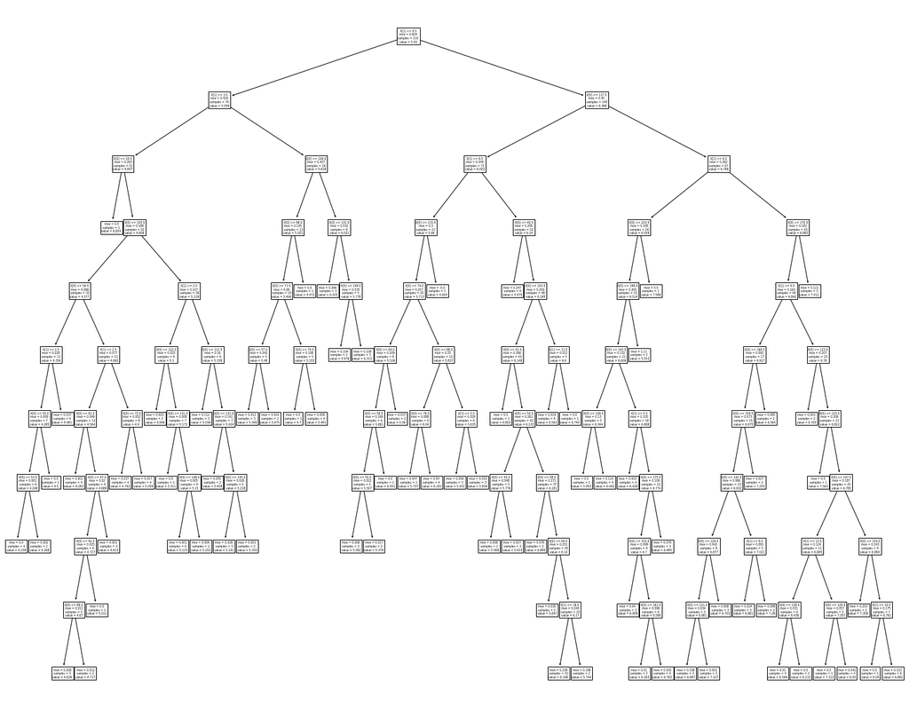

```python
fig = plt.figure(figsize=(25,20))
_=plot_tree(dt)
```

Clearly, this tree is very large. We can tune several paratmers. We can also specify ccp_alpha to do the cost complexity pruning.

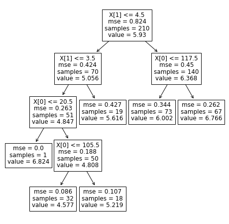

```python
dt_02 = DecisionTreeRegressor(ccp_alpha=0.02)
dt_02.fit(X_train, y_train)
fig = plt.figure(figsize=(8,8))
_ =plot_tree(dt_02)
```

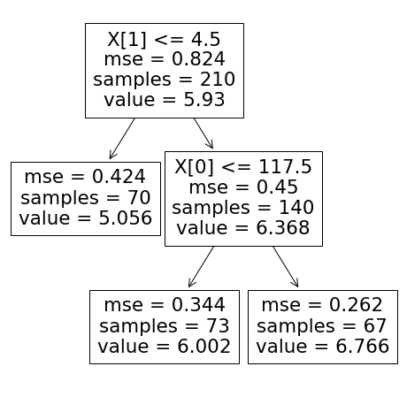

```python
dt_05 = DecisionTreeRegressor(ccp_alpha=0.05)
dt_05.fit(X_train, y_train)
fig = plt.figure(figsize=(8,8))
_ =plot_tree(dt_05)
```

```python
Reduction_SE = 0.824*210 - 0.424*70 - 140*0.45
Reduction_MSE=Reduction_SE/210
Reduction_MSE
```

```
0.3826666666666666
```

Let's check the test MSE for these three tress.

```python
from sklearn.metrics import mean_squared_error as MSE
```

```python
MSE(dt_05.predict(X_test),y_test)
```

```
0.364368991494349
```

```python
MSE(dt_02.predict(X_test),y_test)
```

```
0.19828510672834826
```

```python
MSE(dt.predict(X_test),y_test)
```

```
0.4475386032680281
```

We can see that there is a clear trade-off when setting ccp_alpha. You can also control the complexity by setting other parameters such as max_depth, min_samples_split, min_samples_leaf, min_weight_fraction_leaf. For the meaning of these parameters, you can use the help function on the object.

```python
help(DecisionTreeRegressor)
```

```
Help on class DecisionTreeRegressor in module sklearn.tree._classes:

class DecisionTreeRegressor(sklearn.base.RegressorMixin, BaseDecisionTree)
 |  DecisionTreeRegressor(*, criterion='mse', splitter='best', max_depth=None, min_samples_split=2, min_samples_leaf=1, min_weight_fraction_leaf=0.0, max_features=None, random_state=None, max_leaf_nodes=None, min_impurity_decrease=0.0, min_impurity_split=None, presort='deprecated', ccp_alpha=0.0)
 |  A decision tree regressor.
 |  Read more in the :ref:`User Guide <tree>`.
 |  Parameters
 |  ----------
 |  criterion : {"mse", "friedman_mse", "mae"}, default="mse"
 |      The function to measure the quality of a split. Supported criteria
 |      are "mse" for the mean squared error, which is equal to variance
 |      reduction as feature selection criterion and minimizes the L2 loss
 |      using the mean of each terminal node, "friedman_mse", which uses mean
 |      squared error with Friedman's improvement score for potential splits,
 |      and "mae" for the mean absolute error, which minimizes the L1 loss
 |      using the median of each terminal node.
 |      .. versionadded:: 0.18
 |         Mean Absolute Error (MAE) criterion.
 |  splitter : {"best", "random"}, default="best"
 |      The strategy used to choose the split at each node. Supported
 |      strategies are "best" to choose the best split and "random" to choose
 |      the best random split.
 |  max_depth : int, default=None
 |      The maximum depth of the tree. If None, then nodes are expanded until
 |      all leaves are pure or until all leaves contain less than
 |      min_samples_split samples.
 |  min_samples_split : int or float, default=2
 |      The minimum number of samples required to split an internal node:
 |      - If int, then consider `min_samples_split` as the minimum number.
 |      - If float, then `min_samples_split` is a fraction and
 |        `ceil(min_samples_split * n_samples)` are the minimum
 |        number of samples for each split.
 |      .. versionchanged:: 0.18
 |         Added float values for fractions.
 |  min_samples_leaf : int or float, default=1
 |      The minimum number of samples required to be at a leaf node.
 |      A split point at any depth will only be considered if it leaves at
 |      least ``min_samples_leaf`` training samples in each of the left and
 |      right branches.  This may have the effect of smoothing the model,
 |      especially in regression.
```

[output cut: 333 more lines]

```
 |          Parameter names mapped to their values.
 |  set_params(self, **params)
 |      Set the parameters of this estimator.
 |      The method works on simple estimators as well as on nested objects
 |      (such as pipelines). The latter have parameters of the form
 |      ``<component>__<parameter>`` so that it's possible to update each
 |      component of a nested object.
 |      Parameters
 |      ----------
 |      **params : dict
 |          Estimator parameters.
 |      Returns
 |      -------
 |      self : object
 |          Estimator instance.
```

The importance of each feature can be known from the following code.

```python
dt_02.feature_importances_
```

```
array([0.24781281, 0.75218719])
```

```python
dt_05.feature_importances_
```

```
array([0.20264765, 0.79735235])
```

## Classification Tree

```python
Heart=pd.read_csv('Heart.csv',index_col=0)
Heart = Heart.dropna()
Heart.head()
```

|  | Age | Sex | ChestPain | RestBP | Chol | Fbs | RestECG | MaxHR | ExAng | Oldpeak | Slope | Ca | Thal | AHD |
| --- | --- | --- | --- | --- | --- | --- | --- | --- | --- | --- | --- | --- | --- | --- |
| 1 | 63 | 1 | typical | 145 | 233 | 1 | 2 | 150 | 0 | 2.3 | 3 | 0.0 | fixed | No |
| 2 | 67 | 1 | asymptomatic | 160 | 286 | 0 | 2 | 108 | 1 | 1.5 | 2 | 3.0 | normal | Yes |
| 3 | 67 | 1 | asymptomatic | 120 | 229 | 0 | 2 | 129 | 1 | 2.6 | 2 | 2.0 | reversable | Yes |
| 4 | 37 | 1 | nonanginal | 130 | 250 | 0 | 0 | 187 | 0 | 3.5 | 3 | 0.0 | normal | No |
| 5 | 41 | 0 | nontypical | 130 | 204 | 0 | 2 | 172 | 0 | 1.4 | 1 | 0.0 | normal | No |

```python
from sklearn.tree import DecisionTreeClassifier
```

```python
X=Heart.drop('AHD', axis=1)
X.head()
```

|  | Age | Sex | ChestPain | RestBP | Chol | Fbs | RestECG | MaxHR | ExAng | Oldpeak | Slope | Ca | Thal |
| --- | --- | --- | --- | --- | --- | --- | --- | --- | --- | --- | --- | --- | --- |
| 1 | 63 | 1 | typical | 145 | 233 | 1 | 2 | 150 | 0 | 2.3 | 3 | 0.0 | fixed |
| 2 | 67 | 1 | asymptomatic | 160 | 286 | 0 | 2 | 108 | 1 | 1.5 | 2 | 3.0 | normal |
| 3 | 67 | 1 | asymptomatic | 120 | 229 | 0 | 2 | 129 | 1 | 2.6 | 2 | 2.0 | reversable |
| 4 | 37 | 1 | nonanginal | 130 | 250 | 0 | 0 | 187 | 0 | 3.5 | 3 | 0.0 | normal |
| 5 | 41 | 0 | nontypical | 130 | 204 | 0 | 2 | 172 | 0 | 1.4 | 1 | 0.0 | normal |

```python
X=pd.get_dummies(X)
X.head()
```

|  | Age | Sex | RestBP | Chol | Fbs | RestECG | MaxHR | ExAng | Oldpeak | Slope | Ca | ChestPain_asymptomatic | ChestPain_nonanginal | ChestPain_nontypical | ChestPain_typical | Thal_fixed | Thal_normal | Thal_reversable |
| --- | --- | --- | --- | --- | --- | --- | --- | --- | --- | --- | --- | --- | --- | --- | --- | --- | --- | --- |
| 1 | 63 | 1 | 145 | 233 | 1 | 2 | 150 | 0 | 2.3 | 3 | 0.0 | 0 | 0 | 0 | 1 | 1 | 0 | 0 |
| 2 | 67 | 1 | 160 | 286 | 0 | 2 | 108 | 1 | 1.5 | 2 | 3.0 | 1 | 0 | 0 | 0 | 0 | 1 | 0 |
| 3 | 67 | 1 | 120 | 229 | 0 | 2 | 129 | 1 | 2.6 | 2 | 2.0 | 1 | 0 | 0 | 0 | 0 | 0 | 1 |
| 4 | 37 | 1 | 130 | 250 | 0 | 0 | 187 | 0 | 3.5 | 3 | 0.0 | 0 | 1 | 0 | 0 | 0 | 1 | 0 |
| 5 | 41 | 0 | 130 | 204 | 0 | 2 | 172 | 0 | 1.4 | 1 | 0.0 | 0 | 0 | 1 | 0 | 0 | 1 | 0 |

```python
y=Heart.AHD
```

```python
XX_train, XX_test, yy_train, yy_test = train_test_split(X,y,train_size=int(0.8*len(Heart)), random_state=42)
```

```python
dtc02 = DecisionTreeClassifier(ccp_alpha=0.02)
dtc02.fit(XX_train,yy_train)
```

```
DecisionTreeClassifier(ccp_alpha=0.02)
```

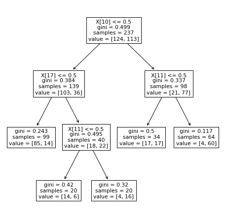

```python
fig = plt.figure(figsize=(8,8))
_ =plot_tree(dtc02)
```

```python
dtc02.classes_
```

```
array(['No', 'Yes'], dtype=object)
```

With the above code, we know the the value corresponse to the occurancy of ['No', 'Yes'] classes. We can also learn the importance of the features through the following code.

```python
dtc02.feature_importances_
```

```
array([0.        , 0.        , 0.        , 0.        , 0.        ,
       0.        , 0.        , 0.        , 0.        , 0.        ,
       0.58086881, 0.24588228, 0.        , 0.        , 0.        ,
       0.        , 0.        , 0.17324891])
```

```python
np.argmax(dtc02.feature_importances_)
```

```
10
```

```python
XX_train.columns
```

```
Index(['Age', 'Sex', 'RestBP', 'Chol', 'Fbs', 'RestECG', 'MaxHR', 'ExAng',
       'Oldpeak', 'Slope', 'Ca', 'ChestPain_asymptomatic',
       'ChestPain_nonanginal', 'ChestPain_nontypical', 'ChestPain_typical',
       'Thal_fixed', 'Thal_normal', 'Thal_reversable'],
      dtype='object')
```

```python
XX_train.columns[10]
```

```
'Ca'
```

```python
XX_train.columns[dtc02.feature_importances_>0.0001]
```

```
Index(['Ca', 'ChestPain_asymptomatic', 'Thal_reversable'], dtype='object')
```

```python
dtc02.predict(XX_test)
```

```
array(['No', 'Yes', 'No', 'Yes', 'No', 'No', 'No', 'No', 'Yes', 'No',
       'No', 'No', 'No', 'Yes', 'No', 'No', 'No', 'Yes', 'No', 'No',
       'Yes', 'No', 'Yes', 'No', 'Yes', 'No', 'Yes', 'Yes', 'No', 'No',
       'No', 'No', 'Yes', 'No', 'No', 'No', 'Yes', 'No', 'Yes', 'Yes',
       'No', 'Yes', 'Yes', 'No', 'No', 'No', 'No', 'No', 'No', 'No', 'No',
       'Yes', 'No', 'No', 'Yes', 'Yes', 'No', 'No', 'Yes', 'No'],
      dtype=object)
```

```python
from sklearn.metrics import confusion_matrix

cm=confusion_matrix(y_true=yy_test,  y_pred=dtc02.predict(XX_test) ).T
cm
```

```
array([[34,  6],
       [ 2, 18]], dtype=int64)
```

```python
from sklearn.metrics import roc_auc_score

roc_auc_score(y_true= yy_test,y_score = dtc02.predict_proba(XX_test)[:,1])
```

```
0.9039351851851851
```

## Bagging and Random Forest

The syntax of random forest is similar to the decision tree. When max_features=None, it is the bagging; otherwise it is the random forest. Default value is max_features=auto, in which case the number of features used is sqrt(n_features). By selecting the oob_score=True, the program will estimate the test error using the OOB data points.

```python
from sklearn.ensemble import RandomForestClassifier
from sklearn.ensemble import RandomForestRegressor
```

```python
Tree_bag=RandomForestClassifier(n_estimators=1000, max_features=None,random_state=42,oob_score=True)
Tree_bag.fit(XX_train,yy_train)
```

```
RandomForestClassifier(max_features=None, n_estimators=1000, oob_score=True,
                       random_state=42)
```

```python
roc_auc_score(y_true= yy_test,y_score = Tree_bag.predict_proba(XX_test)[:,1])
```

```
0.9259259259259259
```

We can check the test accuracy rate also

```python
np.mean(Tree_bag.predict(XX_test)==yy_test)
```

```
0.8333333333333334
```

oob*score* is the generalization error (test error) estimated using out of bag observations

```python
Tree_bag.oob_score_
```

```
0.7763713080168776
```

We can tune the parameters to improve the performance.

```python
Tree_bag=RandomForestClassifier(n_estimators=1000, max_features=None, min_samples_split = 0.2,random_state=42)
Tree_bag.fit(XX_train,yy_train)
roc_auc_score(y_true= yy_test,y_score = Tree_bag.predict_proba(XX_test)[:,1])
```

```
0.9421296296296297
```

How about random forest?

```python
help(RandomForestClassifier)
```

```
Help on class RandomForestClassifier in module sklearn.ensemble._forest:

class RandomForestClassifier(ForestClassifier)
 |  RandomForestClassifier(n_estimators=100, *, criterion='gini', max_depth=None, min_samples_split=2, min_samples_leaf=1, min_weight_fraction_leaf=0.0, max_features='auto', max_leaf_nodes=None, min_impurity_decrease=0.0, min_impurity_split=None, bootstrap=True, oob_score=False, n_jobs=None, random_…
 |  A random forest classifier.
 |  A random forest is a meta estimator that fits a number of decision tree
 |  classifiers on various sub-samples of the dataset and uses averaging to
 |  improve the predictive accuracy and control over-fitting.
 |  The sub-sample size is controlled with the `max_samples` parameter if
 |  `bootstrap=True` (default), otherwise the whole dataset is used to build
 |  each tree.
 |  Read more in the :ref:`User Guide <forest>`.
 |  Parameters
 |  ----------
 |  n_estimators : int, default=100
 |      The number of trees in the forest.
 |      .. versionchanged:: 0.22
 |         The default value of ``n_estimators`` changed from 10 to 100
 |         in 0.22.
 |  criterion : {"gini", "entropy"}, default="gini"
 |      The function to measure the quality of a split. Supported criteria are
 |      "gini" for the Gini impurity and "entropy" for the information gain.
 |      Note: this parameter is tree-specific.
 |  max_depth : int, default=None
 |      The maximum depth of the tree. If None, then nodes are expanded until
 |      all leaves are pure or until all leaves contain less than
 |      min_samples_split samples.
 |  min_samples_split : int or float, default=2
 |      The minimum number of samples required to split an internal node:
 |      - If int, then consider `min_samples_split` as the minimum number.
 |      - If float, then `min_samples_split` is a fraction and
 |        `ceil(min_samples_split * n_samples)` are the minimum
 |        number of samples for each split.
 |      .. versionchanged:: 0.18
 |         Added float values for fractions.
 |  min_samples_leaf : int or float, default=1
 |      The minimum number of samples required to be at a leaf node.
 |      A split point at any depth will only be considered if it leaves at
 |      least ``min_samples_leaf`` training samples in each of the left and
 |      right branches.  This may have the effect of smoothing the model,
```

[output cut: 362 more lines]

```
 |          Parameter names mapped to their values.
 |  set_params(self, **params)
 |      Set the parameters of this estimator.
 |      The method works on simple estimators as well as on nested objects
 |      (such as pipelines). The latter have parameters of the form
 |      ``<component>__<parameter>`` so that it's possible to update each
 |      component of a nested object.
 |      Parameters
 |      ----------
 |      **params : dict
 |          Estimator parameters.
 |      Returns
 |      -------
 |      self : object
 |          Estimator instance.
```

```python
help(RandomForestRegressor)
```

```
Help on class RandomForestRegressor in module sklearn.ensemble._forest:

class RandomForestRegressor(ForestRegressor)
 |  RandomForestRegressor(n_estimators=100, *, criterion='mse', max_depth=None, min_samples_split=2, min_samples_leaf=1, min_weight_fraction_leaf=0.0, max_features='auto', max_leaf_nodes=None, min_impurity_decrease=0.0, min_impurity_split=None, bootstrap=True, oob_score=False, n_jobs=None, random_st…
 |  A random forest regressor.
 |  A random forest is a meta estimator that fits a number of classifying
 |  decision trees on various sub-samples of the dataset and uses averaging
 |  to improve the predictive accuracy and control over-fitting.
 |  The sub-sample size is controlled with the `max_samples` parameter if
 |  `bootstrap=True` (default), otherwise the whole dataset is used to build
 |  each tree.
 |  Read more in the :ref:`User Guide <forest>`.
 |  Parameters
 |  ----------
 |  n_estimators : int, default=100
 |      The number of trees in the forest.
 |      .. versionchanged:: 0.22
 |         The default value of ``n_estimators`` changed from 10 to 100
 |         in 0.22.
 |  criterion : {"mse", "mae"}, default="mse"
 |      The function to measure the quality of a split. Supported criteria
 |      are "mse" for the mean squared error, which is equal to variance
 |      reduction as feature selection criterion, and "mae" for the mean
 |      absolute error.
 |      .. versionadded:: 0.18
 |         Mean Absolute Error (MAE) criterion.
 |  max_depth : int, default=None
 |      The maximum depth of the tree. If None, then nodes are expanded until
 |      all leaves are pure or until all leaves contain less than
 |      min_samples_split samples.
 |  min_samples_split : int or float, default=2
 |      The minimum number of samples required to split an internal node:
 |      - If int, then consider `min_samples_split` as the minimum number.
 |      - If float, then `min_samples_split` is a fraction and
 |        `ceil(min_samples_split * n_samples)` are the minimum
 |        number of samples for each split.
 |      .. versionchanged:: 0.18
 |         Added float values for fractions.
 |  min_samples_leaf : int or float, default=1
 |      The minimum number of samples required to be at a leaf node.
```

[output cut: 320 more lines]

```
 |          Parameter names mapped to their values.
 |  set_params(self, **params)
 |      Set the parameters of this estimator.
 |      The method works on simple estimators as well as on nested objects
 |      (such as pipelines). The latter have parameters of the form
 |      ``<component>__<parameter>`` so that it's possible to update each
 |      component of a nested object.
 |      Parameters
 |      ----------
 |      **params : dict
 |          Estimator parameters.
 |      Returns
 |      -------
 |      self : object
 |          Estimator instance.
```

```python
RF=RandomForestClassifier(n_estimators=1000,min_samples_split = 0.01, max_features='sqrt', random_state=42)
RF.fit(XX_train,yy_train)
roc_auc_score(y_true= yy_test,y_score = RF.predict_proba(XX_test)[:,1])
```

```
0.9571759259259259
```

```python
RF.feature_importances_
```

```
array([0.08966973, 0.02851298, 0.07122303, 0.08305792, 0.01072421,
       0.0170983 , 0.11852561, 0.04790124, 0.09636507, 0.03183486,
       0.13068159, 0.08085965, 0.02418717, 0.00914666, 0.00987611,
       0.00426649, 0.07826695, 0.06780241])
```

```python
np.argmax(RF.feature_importances_)
```

```
10
```

```python
for i in range(len(XX_train.columns)):
    print(XX_train.columns[i],RF.feature_importances_[i])
```

```
Age 0.08966973236547218
Sex 0.028512983076058374
RestBP 0.07122302914712118
Chol 0.08305791686720841
Fbs 0.010724213849372385
RestECG 0.01709830239676967
MaxHR 0.11852560902594891
ExAng 0.04790123794685434
Oldpeak 0.09636506962457358
Slope 0.03183485954096588
Ca 0.13068159174700442
ChestPain_asymptomatic 0.080859654280052
ChestPain_nonanginal 0.024187167835648903
ChestPain_nontypical 0.009146658516237468
ChestPain_typical 0.009876111966429676
Thal_fixed 0.004266494946565788
Thal_normal 0.07826695370345954
Thal_reversable 0.06780241316425735
```

## Gradient Boosting

```python
from  sklearn.ensemble import GradientBoostingClassifier
```

```python
gbc = GradientBoostingClassifier(random_state=31)
gbc.fit(XX_train,yy_train)
roc_auc_score(y_true= yy_test,y_score = gbc.predict_proba(XX_test)[:,1])
```

```
0.8900462962962963
```

```python
gbc = GradientBoostingClassifier(learning_rate=0.005, n_estimators=1000,max_depth=1, max_features=2, random_state=31)
gbc.fit(XX_train,yy_train)
roc_auc_score(y_true= yy_test,y_score = gbc.predict_proba(XX_test)[:,1])
```

```
0.9618055555555556
```

By carefully choosing the parameters, Gradient Boosting methods could work very well. But it is quite sensitive to parameter values.

# Coding Exercise

1. Plot the test ROC curve for the heart data set using random forest and boosting.